# ADL - Using the toilet

# 1 Description of DataSchema variable

- Short name: `adl_toilet`
- Variable label: `ADL-Difficulties for using the toilet`
- Domain: `Health status and functional limitations`
- Value type: `categorical`
- Category coding:

| **Code** | **Category Label** |
| --- | --- |
| 0 | yes |
| 1 | no |

- Category missings:

| **Code** | **Category Label** |
| --- | --- |
| 991 | CAPI/interviewer error |
| 992 | Impute |
| 993 | Disable to measure |
| 994 | Not attempt/not done |
| 995 | Does not answer |
| 996 | Not applicable |
| 997 | Refuse |
| 998 | Do not know |
| 999 | Missing |

# 2 Data process

## 2.1 England

### 2.1.1 Wave 1

#### 2.1.1.1 Study-specific variable description

- Name: `headlwc`
- Label: `ADL: Difficulty using the toilet, including getting up or down`
- Categories:
  - `0 = Not mentioned`
  - `1 = Mentioned`
- Missings
  - `-9 = Refusal`
  - `-8 = Don't know`
  - `-1 = Not applicable`
- Description:

| Sample size | Missing values |
| --- | --- |
| 12099 | 0 |

Category

|  | -9 | -8 | -1 | 0 | 1 |
| --- | --- | --- | --- | --- | --- |
| Frequency | 4.00 | 12.0 | 175.00 | 11489.00 | 419.00 |
| Percentage | 0.03 | 0.1 | 1.45 | 94.96 | 3.46 |

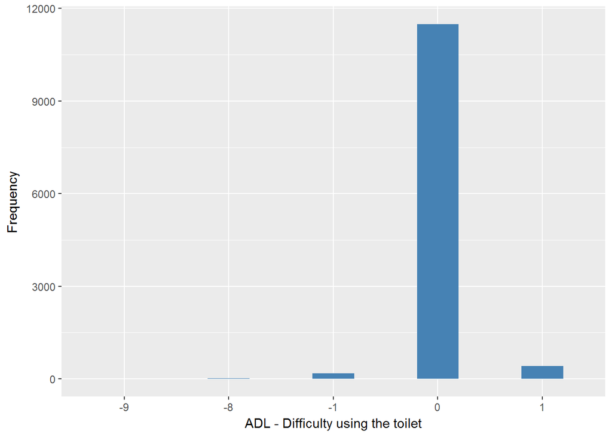

#### 2.1.1.2 Harmonisation algorithm

To compute the harmonize variable from the study-specific variable it has to be recoded as follows:

- `1 into 0`
- `0 into 1`
- `-9 Refusal into 997`
- `-8 Don't know into 998`
- `-1 Not applicable into 996`

**R script:**

```r
ELSA_ds_w1 <- tibble(id = ELSA_w1_adl_toilet$id)
ELSA_ds_w1$adl_toilet <- car::recode(ELSA_w1_adl_toilet$headlwc, "0 = '1';1 = '0';-9 = '997';-8 = '998';-1 = '996' ")
ELSA_ds_w1$adl_toilet <- labelled(ELSA_ds_w1$adl_toilet, labels = c(Yes = 0,
    No = 1, Missing = 999, Do_not_know = 998, Refuse = 997, Not_applicable = 996,
    Does_not_answer = 995, Not_attempt_not_done = 994, Disable_to_measure = 993,
    Impute = 992, CAPI_interviewer_error = 991))
```

#### 2.1.1.3 Statistical description of the new harmonised variable

adl_toilet

| Sample size | Missing values |
| --- | --- |
| 12099 | 191 |

Category

|  | 0 | 1 |
| --- | --- | --- |
| Frequency | 419.00 | 11489.00 |
| Percentage | 3.46 | 94.96 |

Type of missing

|  | 991 | 992 | 993 | 994 | 995 | 996 | 997 | 998 | 999 | NA |
| --- | --- | --- | --- | --- | --- | --- | --- | --- | --- | --- |
| Frequency | 0 | 0 | 0 | 0 | 0 | 175.00 | 4.00 | 12.0 | 0 | 0 |
| Percentage | 0 | 0 | 0 | 0 | 0 | 1.45 | 0.03 | 0.1 | 0 | 0 |

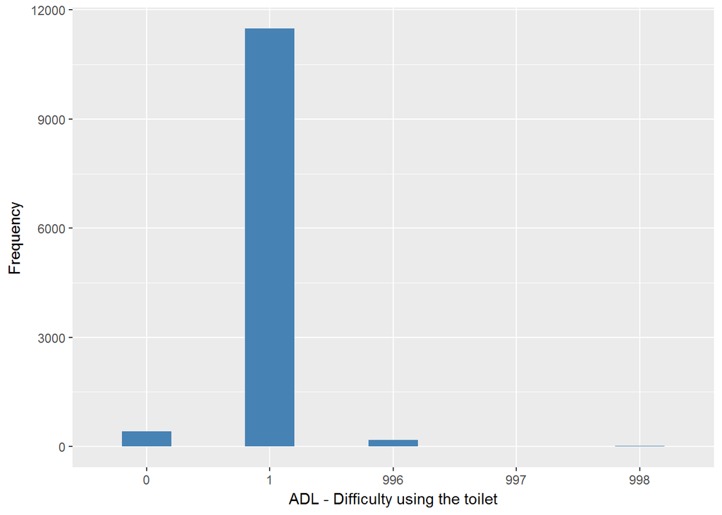

#### 2.1.1.4 Validation

|  | 1->0 | 0->1 | -1->996 | -9->997 | -8->998 |
| --- | --- | --- | --- | --- | --- |
| BeforeH | 419 | 11489 | 175 | 4 | 12 |
| AfterH | 419 | 11489 | 175 | 4 | 12 |

### 2.1.2 Wave 2

#### 2.1.2.1 Study-specific variable description

- Name: `headlwc`
- Label: `ADL: Difficulty using the toilet, including getting up or down`
- Categories:
  - `0 = Not mentioned`
  - `1 = Mentioned`
- Missings
  - `-9 = Refusal`
  - `-8 = Don't know`
- Description:

| Sample size | Missing values |
| --- | --- |
| 9432 | 0 |

Category

|  | -9 | -8 | 0 | 1 |
| --- | --- | --- | --- | --- |
| Frequency | 2.00 | 1.00 | 9118.00 | 311.0 |
| Percentage | 0.02 | 0.01 | 96.67 | 3.3 |

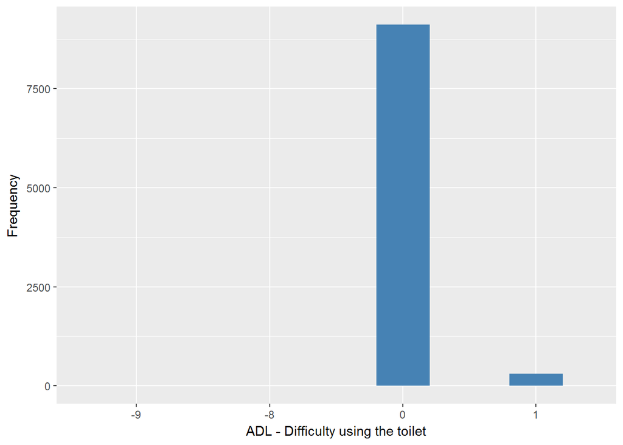

#### 2.1.2.2 Harmonisation algorithm

To compute the harmonize variable from the study-specific variable it has to be recoded as follows:

- `1 into 0`
- `0 into 1`
- `-9 Refusal into 997`
- `-8 Don't know into 998`

**R script:**

```r
ELSA_ds_w2 <- tibble(id = ELSA_w2_adl_toilet$id)
ELSA_ds_w2$adl_toilet <- car::recode(ELSA_w2_adl_toilet$headlwc, "0 = '1';1 = '0';-9 = '997';-8 = '998';-1 = '996' ")
ELSA_ds_w2$adl_toilet <- labelled(ELSA_ds_w2$adl_toilet, labels = c(Yes = 0,
    No = 1, Missing = 999, Do_not_know = 998, Refuse = 997, Not_applicable = 996,
    Does_not_answer = 995, Not_attempt_not_done = 994, Disable_to_measure = 993,
    Impute = 992, CAPI_interviewer_error = 991))
```

#### 2.1.2.3 Statistical description of the new harmonised variable

adl_toilet

| Sample size | Missing values |
| --- | --- |
| 9432 | 3 |

Category

|  | 0 | 1 |
| --- | --- | --- |
| Frequency | 311.0 | 9118.00 |
| Percentage | 3.3 | 96.67 |

Type of missing

|  | 991 | 992 | 993 | 994 | 995 | 996 | 997 | 998 | 999 | NA |
| --- | --- | --- | --- | --- | --- | --- | --- | --- | --- | --- |
| Frequency | 0 | 0 | 0 | 0 | 0 | 0 | 2.00 | 1.00 | 0 | 0 |
| Percentage | 0 | 0 | 0 | 0 | 0 | 0 | 0.02 | 0.01 | 0 | 0 |

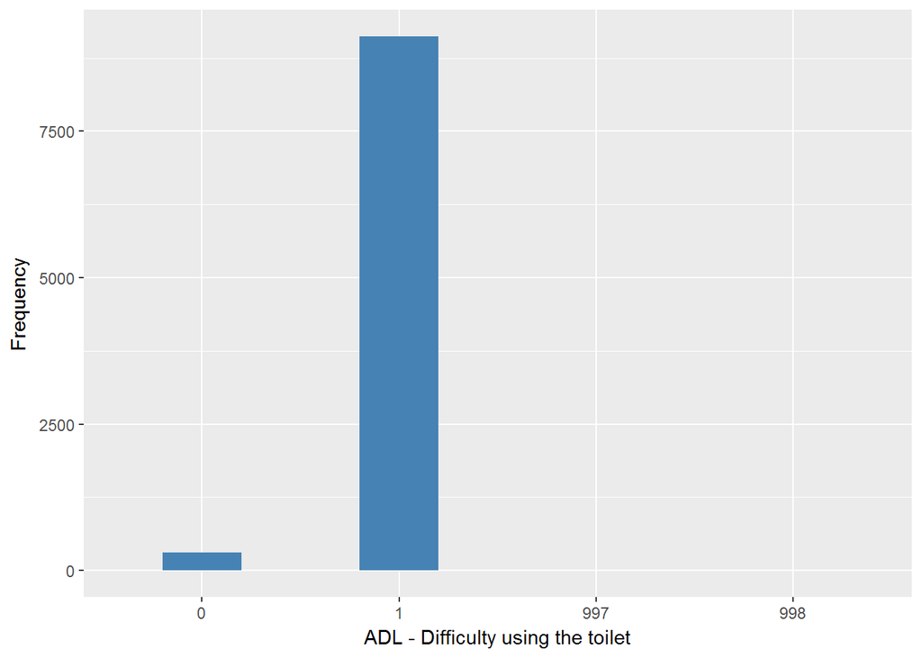

#### 2.1.2.4 Validation

|  | 1->0 | 0->1 | -9->997 | -8->998 |
| --- | --- | --- | --- | --- |
| BeforeH | 311 | 9118 | 2 | 1 |
| AfterH | 311 | 9118 | 2 | 1 |

### 2.1.3 Wave 3

#### 2.1.3.1 Study-specific variable description

- Name: `headlwc`
- Label: `ADL: Difficulty using the toilet, including getting up or down`
- Categories:
  - `0 = Not mentioned`
  - `1 = Mentioned`
- Missings
  - `-1 = Not applicable`
- Description:

HEADLWC

| Sample size | Missing values |
| --- | --- |
| 9771 | 0 |

Category

|  | -1 | 0 | 1 |
| --- | --- | --- | --- |
| Frequency | 4.00 | 9402.00 | 365.00 |
| Percentage | 0.04 | 96.22 | 3.74 |

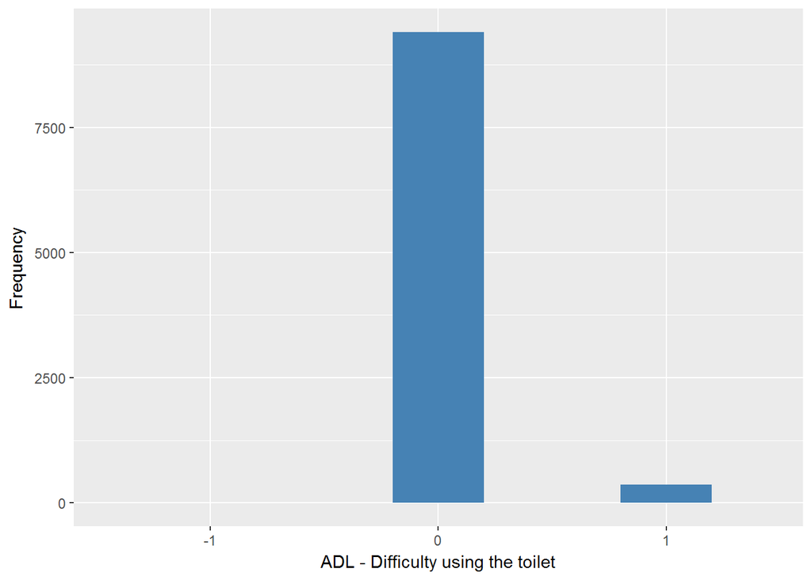

#### 2.1.3.2 Harmonisation algorithm

To compute the harmonize variable from the study-specific variable it has to be recoded as follows:

- `1 into 0`
- `0 into 1`
- `-1 Not applicable into 996`

**R script:**

```r
ELSA_ds_w3 <- tibble(id = ELSA_w3_adl_toilet$id)
ELSA_ds_w3$adl_toilet <- car::recode(ELSA_w3_adl_toilet$headlwc, "0 = '1';1 = '0';-9 = '997';-8 = '998';-1 = '996' ")
ELSA_ds_w3$adl_toilet <- labelled(ELSA_ds_w3$adl_toilet, labels = c(Yes = 0,
    No = 1, Missing = 999, Do_not_know = 998, Refuse = 997, Not_applicable = 996,
    Does_not_answer = 995, Not_attempt_not_done = 994, Disable_to_measure = 993,
    Impute = 992, CAPI_interviewer_error = 991))
```

#### 2.1.3.3 Statistical description of the new harmonised variable

adl_toilet

| Sample size | Missing values |
| --- | --- |
| 9771 | 4 |

Category

|  | 0 | 1 |
| --- | --- | --- |
| Frequency | 365.00 | 9402.00 |
| Percentage | 3.74 | 96.22 |

Type of missing

|  | 991 | 992 | 993 | 994 | 995 | 996 | 997 | 998 | 999 | NA |
| --- | --- | --- | --- | --- | --- | --- | --- | --- | --- | --- |
| Frequency | 0 | 0 | 0 | 0 | 0 | 4.00 | 0 | 0 | 0 | 0 |
| Percentage | 0 | 0 | 0 | 0 | 0 | 0.04 | 0 | 0 | 0 | 0 |

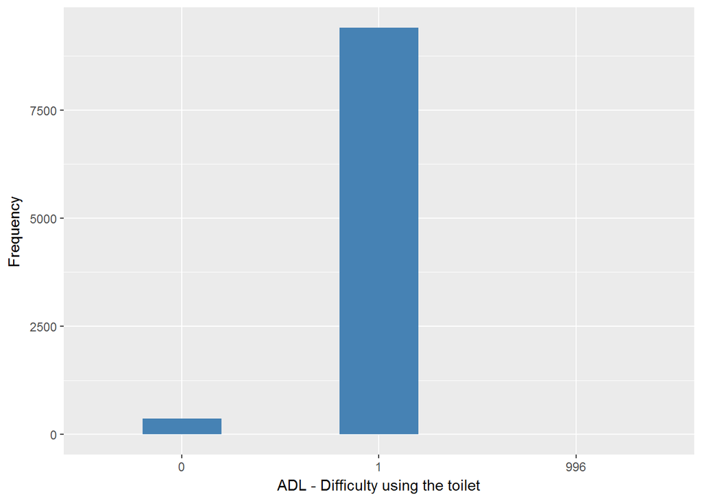

#### 2.1.3.4 Validation

|  | 1->0 | 0->1 | -1->996 |
| --- | --- | --- | --- |
| BeforeH | 365 | 9402 | 4 |
| AfterH | 365 | 9402 | 4 |

### 2.1.4 Wave 4

#### 2.1.4.1 Study-specific variable description

- Name: `headlwc`
- Label: `ADL: Difficulty using the toilet, including getting up or down`
- Categories:
  - `0 = Not mentioned`
  - `1 = Mentioned`
- Missings
  - `-9 = Refusal`
  - `-8 = Don't know`
- Description:

| Sample size | Missing values |
| --- | --- |
| 11050 | 0 |

Category

|  | -9 | -8 | 0 | 1 |
| --- | --- | --- | --- | --- |
| Frequency | 7.00 | 2.00 | 10663.0 | 378.00 |
| Percentage | 0.06 | 0.02 | 96.5 | 3.42 |

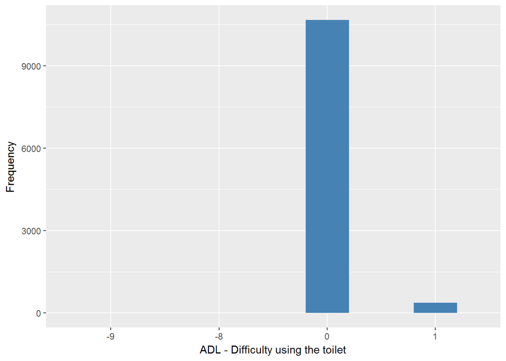

#### 2.1.4.2 Harmonisation algorithm

To compute the harmonize variable from the study-specific variable it has to be recoded as follows:

- `1 into 0`
- `0 into 1`
- `-9 Refusal into 997`
- `-8 Don't know into 998`

**R script:**

```r
ELSA_ds_w4 <- tibble(id = ELSA_w4_adl_toilet$id)
ELSA_ds_w4$adl_toilet <- car::recode(ELSA_w4_adl_toilet$headlwc, "0 = '1';1 = '0';-9 = '997';-8 = '998';-1 = '996' ")
ELSA_ds_w4$adl_toilet <- labelled(ELSA_ds_w4$adl_toilet, labels = c(Yes = 0,
    No = 1, Missing = 999, Do_not_know = 998, Refuse = 997, Not_applicable = 996,
    Does_not_answer = 995, Not_attempt_not_done = 994, Disable_to_measure = 993,
    Impute = 992, CAPI_interviewer_error = 991))
```

#### 2.1.4.3 Statistical description of the new harmonised variable

adl_toilet

| Sample size | Missing values |
| --- | --- |
| 11050 | 9 |

Category

|  | 0 | 1 |
| --- | --- | --- |
| Frequency | 378.00 | 10663.0 |
| Percentage | 3.42 | 96.5 |

Type of missing

|  | 991 | 992 | 993 | 994 | 995 | 996 | 997 | 998 | 999 | NA |
| --- | --- | --- | --- | --- | --- | --- | --- | --- | --- | --- |
| Frequency | 0 | 0 | 0 | 0 | 0 | 0 | 7.00 | 2.00 | 0 | 0 |
| Percentage | 0 | 0 | 0 | 0 | 0 | 0 | 0.06 | 0.02 | 0 | 0 |

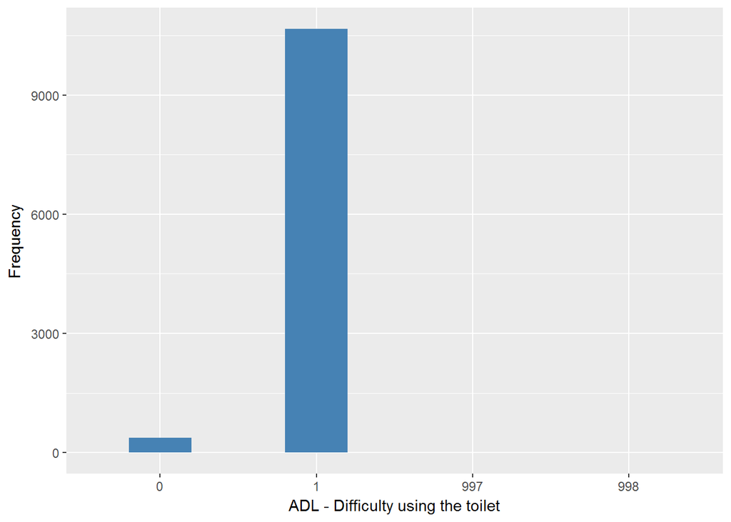

#### 2.1.4.4 Validation

|  | 1->0 | 0->1 | -9->997 | -8->998 |
| --- | --- | --- | --- | --- |
| BeforeH | 378 | 10663 | 7 | 2 |
| AfterH | 378 | 10663 | 7 | 2 |

### 2.1.5 Wave 5

#### 2.1.5.1 Study-specific variable description

- Name: `headlwc`
- Label: `ADL: Difficulty using the toilet, including getting up or down`
- Categories:
  - `0 = Not mentioned`
  - `1 = Mentioned`
- Missings
  - `-9 = Refusal`
  - `-8 = Don't know`
- Description:

| Sample size | Missing values |
| --- | --- |
| 10274 | 0 |

Category

|  | -9 | -8 | 0 | 1 |
| --- | --- | --- | --- | --- |
| Frequency | 5.00 | 3.00 | 9896.00 | 370.0 |
| Percentage | 0.05 | 0.03 | 96.32 | 3.6 |

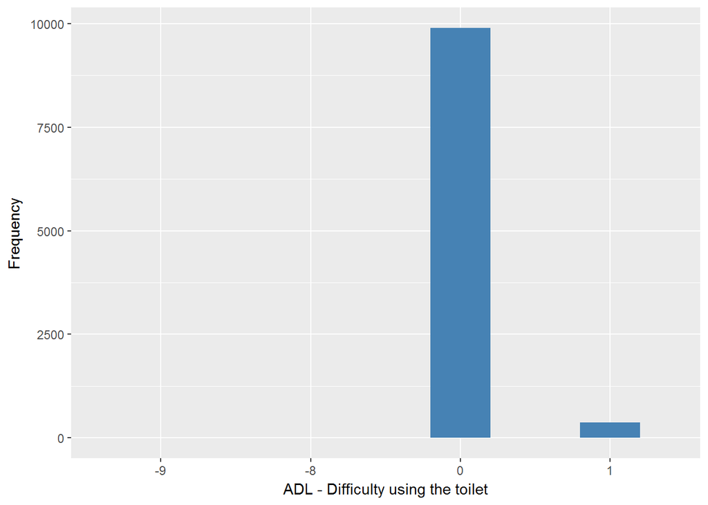

#### 2.1.5.2 Harmonisation algorithm

To compute the harmonize variable from the study-specific variable it has to be recoded as follows:

- `1 into 0`
- `0 into 1`
- `-9 Refusal into 997`
- `-8 Don't know into 998`

**R script:**

```r
ELSA_ds_w5 <- tibble(id = ELSA_w5_adl_toilet$id)
ELSA_ds_w5$adl_toilet <- car::recode(ELSA_w5_adl_toilet$headlwc, "0 = '1';1 = '0';-9 = '997';-8 = '998';-1 = '996' ")
ELSA_ds_w5$adl_toilet <- labelled(ELSA_ds_w5$adl_toilet, labels = c(Yes = 0,
    No = 1, Missing = 999, Do_not_know = 998, Refuse = 997, Not_applicable = 996,
    Does_not_answer = 995, Not_attempt_not_done = 994, Disable_to_measure = 993,
    Impute = 992, CAPI_interviewer_error = 991))
```

#### 2.1.5.3 Statistical description of the new harmonised variable

adl_toilet

| Sample size | Missing values |
| --- | --- |
| 10274 | 8 |

Category

|  | 0 | 1 |
| --- | --- | --- |
| Frequency | 370.0 | 9896.00 |
| Percentage | 3.6 | 96.32 |

Type of missing

|  | 991 | 992 | 993 | 994 | 995 | 996 | 997 | 998 | 999 | NA |
| --- | --- | --- | --- | --- | --- | --- | --- | --- | --- | --- |
| Frequency | 0 | 0 | 0 | 0 | 0 | 0 | 5.00 | 3.00 | 0 | 0 |
| Percentage | 0 | 0 | 0 | 0 | 0 | 0 | 0.05 | 0.03 | 0 | 0 |

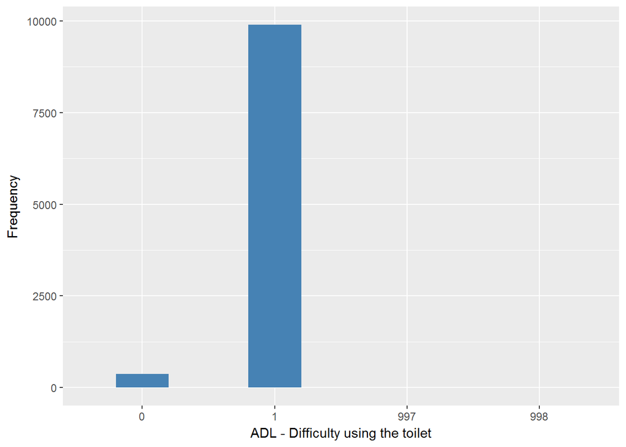

#### 2.1.5.4 Validation

|  | 1->0 | 0->1 | -9->997 | -8->998 |
| --- | --- | --- | --- | --- |
| BeforeH | 370 | 9896 | 5 | 3 |
| AfterH | 370 | 9896 | 5 | 3 |

### 2.1.6 Wave 6

#### 2.1.6.1 Study-specific variable description

- Name: `headlwc`
- Label: `ADL: Difficulty using the toilet, including getting up or down`
- Categories:
  - `0 = Not mentioned`
  - `1 = Mentioned`
- Missings
  - `-9 = Refusal`
  - `-8 = Don't know`
- Description:

HEADLWC

| Sample size | Missing values |
| --- | --- |
| 10601 | 0 |

Category

|  | -9 | -8 | 0 | 1 |
| --- | --- | --- | --- | --- |
| Frequency | 3.00 | 2.00 | 10211.00 | 385.00 |
| Percentage | 0.03 | 0.02 | 96.32 | 3.63 |

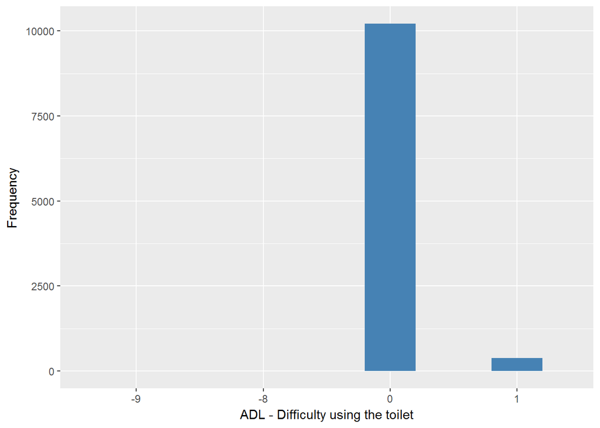

#### 2.1.6.2 Harmonisation algorithm

To compute the harmonize variable from the study-specific variable it has to be recoded as follows:

- `1 into 0`
- `0 into 1`
- `-9 Refusal into 997`
- `-8 Don't know into 998`

**R script:**

```r
ELSA_ds_w6 <- tibble(id = ELSA_w6_adl_toilet$id)
ELSA_ds_w6$adl_toilet <- car::recode(ELSA_w6_adl_toilet$headlwc, "0 = '1';1 = '0';-9 = '997';-8 = '998';-1 = '996' ")
ELSA_ds_w6$adl_toilet <- labelled(ELSA_ds_w6$adl_toilet, labels = c(Yes = 0,
    No = 1, Missing = 999, Do_not_know = 998, Refuse = 997, Not_applicable = 996,
    Does_not_answer = 995, Not_attempt_not_done = 994, Disable_to_measure = 993,
    Impute = 992, CAPI_interviewer_error = 991))
```

#### 2.1.6.3 Statistical description of the new harmonised variable

| Sample size | Missing values |
| --- | --- |
| 10601 | 5 |

Category

|  | 0 | 1 |
| --- | --- | --- |
| Frequency | 385.00 | 10211.00 |
| Percentage | 3.63 | 96.32 |

Type of missing

|  | 991 | 992 | 993 | 994 | 995 | 996 | 997 | 998 | 999 | NA |
| --- | --- | --- | --- | --- | --- | --- | --- | --- | --- | --- |
| Frequency | 0 | 0 | 0 | 0 | 0 | 0 | 3.00 | 2.00 | 0 | 0 |
| Percentage | 0 | 0 | 0 | 0 | 0 | 0 | 0.03 | 0.02 | 0 | 0 |

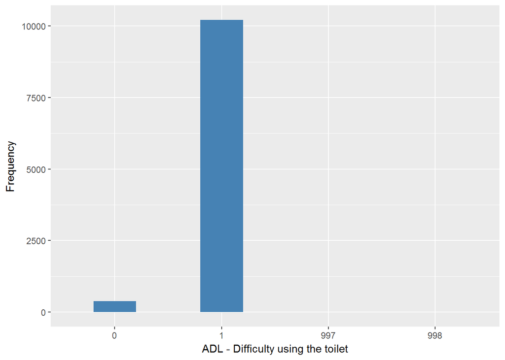

#### 2.1.6.4 Validation

|  | 1->0 | 0->1 | -9->997 | -8->998 |
| --- | --- | --- | --- | --- |
| BeforeH | 385 | 10211 | 3 | 2 |
| AfterH | 385 | 10211 | 3 | 2 |

### 2.1.7 Wave 7

#### 2.1.7.1 Study-specific variable description

- Name: `headlwc`
- Label: `ADL: Difficulty using the toilet, including getting up or down`
- Categories:
  - `0 = Not mentioned`
  - `1 = Mentioned`
- Missings
  - `-8 = Don't know`
- Description:

| Sample size | Missing values |
| --- | --- |
| 9666 | 0 |

Category

|  | -8 | 0 | 1 |
| --- | --- | --- | --- |
| Frequency | 2.00 | 9281.00 | 383.00 |
| Percentage | 0.02 | 96.02 | 3.96 |

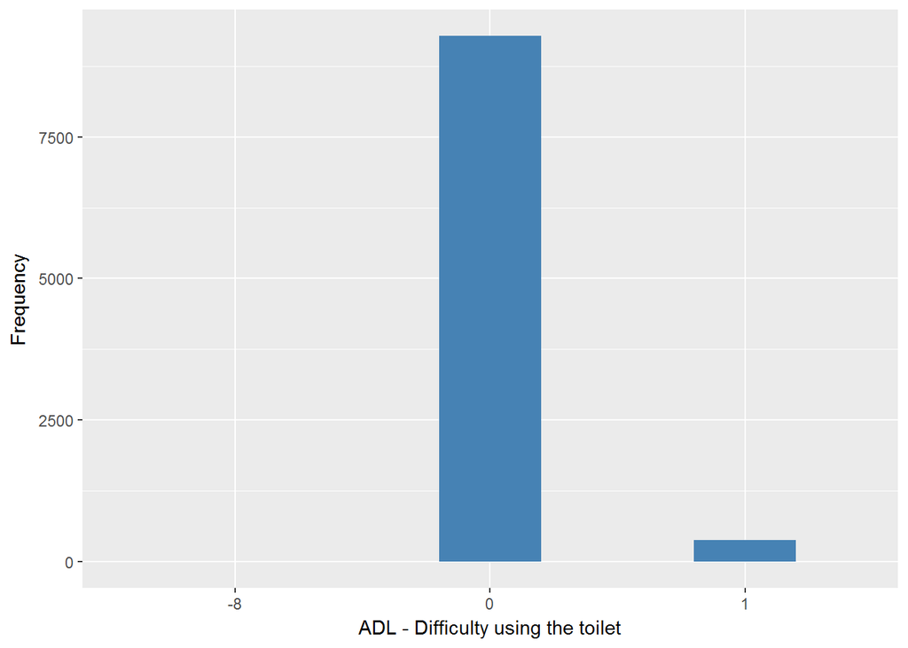

#### 2.1.7.2 Harmonisation algorithm

To compute the harmonize variable from the study-specific variable it has to be recoded as follows:

- `1 into 0`
- `0 into 1`
- `-8 Don't know into 998`

**R script:**

```r
ELSA_ds_w7 <- tibble(id = ELSA_w7_adl_toilet$id)
ELSA_ds_w7$adl_toilet <- car::recode(ELSA_w7_adl_toilet$headlwc, "0 = '1';1 = '0';-9 = '997';-8 = '998';-1 = '996' ")
ELSA_ds_w7$adl_toilet <- labelled(ELSA_ds_w7$adl_toilet, labels = c(Yes = 0,
    No = 1, Missing = 999, Do_not_know = 998, Refuse = 997, Not_applicable = 996,
    Does_not_answer = 995, Not_attempt_not_done = 994, Disable_to_measure = 993,
    Impute = 992, CAPI_interviewer_error = 991))
```

#### 2.1.7.3 Statistical description of the new harmonised variable

adl_toilet

| Sample size | Missing values |
| --- | --- |
| 9666 | 2 |

Category

|  | 0 | 1 |
| --- | --- | --- |
| Frequency | 383.00 | 9281.00 |
| Percentage | 3.96 | 96.02 |

Type of missing

|  | 991 | 992 | 993 | 994 | 995 | 996 | 997 | 998 | 999 | NA |
| --- | --- | --- | --- | --- | --- | --- | --- | --- | --- | --- |
| Frequency | 0 | 0 | 0 | 0 | 0 | 0 | 0 | 2.00 | 0 | 0 |
| Percentage | 0 | 0 | 0 | 0 | 0 | 0 | 0 | 0.02 | 0 | 0 |

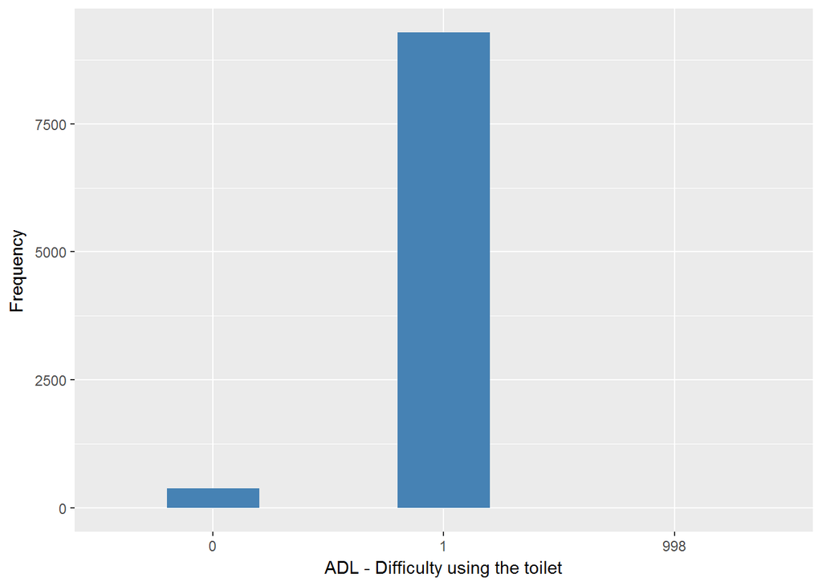

#### 2.1.7.4 Validation

|  | 1->0 | 0->1 | -8->998 |
| --- | --- | --- | --- |
| BeforeH | 383 | 9281 | 2 |
| AfterH | 383 | 9281 | 2 |

# 3 Quality control

No comments.

### 3.0.1 Summary of descriptive statistics of the harmonised variable accross populations and waves

Two tables are generated:

1. Percentages of categories in each harmonised variable.
2. Frequencies and percentages of individuals with different trajectories. To avoid too large table, Only trajectories with percentages larger than 0.3 are shown.

| val | label | w1 | w2 | w3 | w4 | w5 | w6 | w7 |
| --- | --- | --- | --- | --- | --- | --- | --- | --- |
| 0 | Presence | 3.46 | 3.3 | 3.74 | 3.42 | 3.6 | 3.63 | 3.96 |
| 1 | Absence | 94.96 | 96.67 | 96.22 | 96.5 | 96.32 | 96.32 | 96.02 |
| 991 | CAPI_interviewer_error | 0 | 0 | 0 | 0 | 0 | 0 | 0 |
| 992 | Impute | 0 | 0 | 0 | 0 | 0 | 0 | 0 |
| 993 | Disable_to_measure | 0 | 0 | 0 | 0 | 0 | 0 | 0 |
| 994 | Not_attempt_not_done | 0 | 0 | 0 | 0 | 0 | 0 | 0 |
| 995 | Does_not_answer | 0 | 0 | 0 | 0 | 0 | 0 | 0 |
| 996 | Not_applicable | 1.45 | 0 | 0.04 | 0 | 0 | 0 | 0 |
| 997 | Refuse | 0.03 | 0.02 | 0 | 0.06 | 0.05 | 0.03 | 0 |
| 998 | Do_not_know | 0.1 | 0.01 | 0 | 0.02 | 0.03 | 0.02 | 0.02 |
| 999 | Missing | 0 | 0 | 0 | 0 | 0 | 0 | 0 |
| NA | NA | 0 | 0 | 0 | 0 | 0 | 0 | 0 |
| n | sample size | 12099 | 9432 | 9771 | 11050 | 10274 | 10601 | 9666 |

|  | val | frq | raw.prc |
| --- | --- | --- | --- |
| 108 | 0NANANANANANA | 111 | 0.60 |
| 216 | 1111110 | 84 | 0.45 |
| 217 | 1111111 | 3893 | 21.06 |
| 218 | 111111NA | 550 | 2.97 |
| 220 | 11111NA1 | 59 | 0.32 |
| 221 | 11111NANA | 391 | 2.11 |
| 226 | 1111NA11 | 57 | 0.31 |
| 230 | 1111NANANA | 529 | 2.86 |
| 239 | 111NA111 | 106 | 0.57 |
| 240 | 111NA11NA | 55 | 0.30 |
| 248 | 111NANANANA | 802 | 4.34 |
| 261 | 11NA1111 | 105 | 0.57 |
| 282 | 11NANANANANA | 1176 | 6.36 |
| 302 | 1NA11111 | 89 | 0.48 |
| 317 | 1NA1NANANANA | 86 | 0.47 |
| 324 | 1NANA1111 | 65 | 0.35 |
| 348 | 1NANANANANANA | 1888 | 10.21 |
| 423 | NANA11111 | 806 | 4.36 |
| 424 | NANA1111NA | 114 | 0.62 |
| 426 | NANA111NANA | 86 | 0.47 |
| 431 | NANA11NANANA | 120 | 0.65 |
| 438 | NANA1NA111 | 57 | 0.31 |
| 446 | NANA1NANANANA | 297 | 1.61 |
| 477 | NANANA1111 | 1584 | 8.57 |
| 478 | NANANA111NA | 241 | 1.30 |
| 480 | NANANA11NANA | 170 | 0.92 |
| 488 | NANANA1NANANA | 347 | 1.88 |
| 492 | NANANANA111 | 80 | 0.43 |
| 501 | NANANANANA11 | 924 | 5.00 |
| 502 | NANANANANA1NA | 266 | 1.44 |
| 504 | NANANANANANA1 | 498 | 2.69 |
| 505 | NANANANANANANA | 92 | 0.50 |